# Clase 2 - Avanzando con R

David Hervás

20/12/2018

## Funciones de la familia apply

El otro día ya comentamos que en R existen alternativas al uso de bucles for. Dentro de estas alternativas están las funciones de la familia apply (apply, sapply, lapply y tapply entreo otras).

### apply:

Aplica una función a cada fila (1) o columna (2) de una matrix. La función puede existir o definirse en la misma llamada a apply

```r
x <- matrix(1:100, ncol=5)
x
```

```
##       [,1] [,2] [,3] [,4] [,5]
##  [1,]    1   21   41   61   81
##  [2,]    2   22   42   62   82
##  [3,]    3   23   43   63   83
##  [4,]    4   24   44   64   84
##  [5,]    5   25   45   65   85
##  [6,]    6   26   46   66   86
##  [7,]    7   27   47   67   87
##  [8,]    8   28   48   68   88
##  [9,]    9   29   49   69   89
## [10,]   10   30   50   70   90
## [11,]   11   31   51   71   91
## [12,]   12   32   52   72   92
## [13,]   13   33   53   73   93
## [14,]   14   34   54   74   94
## [15,]   15   35   55   75   95
## [16,]   16   36   56   76   96
## [17,]   17   37   57   77   97
## [18,]   18   38   58   78   98
## [19,]   19   39   59   79   99
## [20,]   20   40   60   80  100
```

```r
apply(x, 1, mean)
```

```
##  [1] 41 42 43 44 45 46 47 48 49 50 51 52 53 54 55 56 57 58 59 60
```

```r
apply(x, 1, median)
```

```
##  [1] 41 42 43 44 45 46 47 48 49 50 51 52 53 54 55 56 57 58 59 60
```

```r
apply(x, 1, function(x) mean(x)/sd(x))
```

```
##  [1] 1.296534 1.328157 1.359779 1.391402 1.423025 1.454648 1.486271
##  [8] 1.517893 1.549516 1.581139 1.612762 1.644384 1.676007 1.707630
## [15] 1.739253 1.770875 1.802498 1.834121 1.865744 1.897367
```

```r
apply(x, 2, mean)
```

```
## [1] 10.5 30.5 50.5 70.5 90.5
```

### lapply:

Aplica una función a cada elemento de un vector o una lista (o un objeto coercionable a lista). Los data.frames son coercionables a listas, por lo que nos sirve para data.frames

```r
iris
```

```
##     Sepal.Length Sepal.Width Petal.Length Petal.Width    Species
## 1            5.1         3.5          1.4         0.2     setosa
## 2            4.9         3.0          1.4         0.2     setosa
## 3            4.7         3.2          1.3         0.2     setosa
## 4            4.6         3.1          1.5         0.2     setosa
## 5            5.0         3.6          1.4         0.2     setosa
## 6            5.4         3.9          1.7         0.4     setosa
## 7            4.6         3.4          1.4         0.3     setosa
## 8            5.0         3.4          1.5         0.2     setosa
## 9            4.4         2.9          1.4         0.2     setosa
## 10           4.9         3.1          1.5         0.1     setosa
## 11           5.4         3.7          1.5         0.2     setosa
## 12           4.8         3.4          1.6         0.2     setosa
## 13           4.8         3.0          1.4         0.1     setosa
## 14           4.3         3.0          1.1         0.1     setosa
```

[output cut: 136 more lines]

```r
lapply(iris, function(x) mean(x))
```

```
## $Sepal.Length
## [1] 5.843333
##
## $Sepal.Width
## [1] 3.057333
##
## $Petal.Length
## [1] 3.758
##
## $Petal.Width
## [1] 1.199333
##
## $Species
## [1] NA
```

```r
apply(iris, 2, function(x) mean(x))
```

```
## Sepal.Length  Sepal.Width Petal.Length  Petal.Width      Species
##           NA           NA           NA           NA           NA
```

¿Por qué apply no funciona? Porque una de las variables no es numérica. Como apply trabaja con matrices, intenta hacer una matriz con los datos, y al haber una variable categórica y tener que ser las matrices todas del mismo tipo, produce una matriz de caracteres en vez de de números. lapply, sin embargo, coerciona a lista, que puede tener distintos tipos de dato, por lo que las variables numéricas se mantienen y se puede calcular su media. La variable categórica obviamente da error.

lapply nos puede servir para aplicar un test estadístico de forma iterativa sobre distintas variables de un data.frame. Por ejemplo, vamos a ver si existen diferencias entre las especies setosa y virginica para cada una de las variables del data.frame iris.

```r
iris_filtered <- iris[iris$Species %in% c("setosa", "virginica"),]
results <- lapply(iris_filtered[, -5], function(x) t.test(x ~ Species, data=iris_filtered))
results$Sepal.Length
```

```
##
##  Welch Two Sample t-test
##
## data:  x by Species
## t = -15.386, df = 76.516, p-value < 2.2e-16
## alternative hypothesis: true difference in means is not equal to 0
## 95 percent confidence interval:
##  -1.78676 -1.37724
## sample estimates:
##    mean in group setosa mean in group virginica
##                   5.006                   6.588
```

```r
results$Sepal.Width
```

```
##
##  Welch Two Sample t-test
##
## data:  x by Species
## t = 6.4503, df = 95.547, p-value = 4.571e-09
## alternative hypothesis: true difference in means is not equal to 0
## 95 percent confidence interval:
##  0.3142808 0.5937192
## sample estimates:
##    mean in group setosa mean in group virginica
##                   3.428                   2.974
```

### sapply

En este mismo sentido funciona sapply, que es igual que lapply, pero simplificando los resultados cuando sea posible. Por ejemplo:

```r
lapply(iris[, -5], mean)
```

```
## $Sepal.Length
## [1] 5.843333
##
## $Sepal.Width
## [1] 3.057333
##
## $Petal.Length
## [1] 3.758
##
## $Petal.Width
## [1] 1.199333
```

```r
sapply(iris[, -5], mean)
```

```
## Sepal.Length  Sepal.Width Petal.Length  Petal.Width
##     5.843333     3.057333     3.758000     1.199333
```

Simplifica los resultados a un vector. Y

```r
lapply(iris[,-5], quantile)
```

```
## $Sepal.Length
##   0%  25%  50%  75% 100%
##  4.3  5.1  5.8  6.4  7.9
##
## $Sepal.Width
##   0%  25%  50%  75% 100%
##  2.0  2.8  3.0  3.3  4.4
##
## $Petal.Length
##   0%  25%  50%  75% 100%
## 1.00 1.60 4.35 5.10 6.90
##
## $Petal.Width
##   0%  25%  50%  75% 100%
##  0.1  0.3  1.3  1.8  2.5
```

```r
sapply(iris[,-5], quantile)
```

```
##      Sepal.Length Sepal.Width Petal.Length Petal.Width
## 0%            4.3         2.0         1.00         0.1
## 25%           5.1         2.8         1.60         0.3
## 50%           5.8         3.0         4.35         1.3
## 75%           6.4         3.3         5.10         1.8
## 100%          7.9         4.4         6.90         2.5
```

Simplifica los resultados a una matriz. La simplificación de resultados puede ser muy util para luego acceder a los mismos o para facilitar los gráficos.

### tapply

Por último, comentar la función tapply, que sirve para aplicar una función a un vector de manera estratificada según una variable factor. Por ejemplo, calcular las medias de Sepal.Length para cada especie de iris

```r
tapply(iris$Sepal.Length, iris$Species, mean)
```

```
##     setosa versicolor  virginica
##      5.006      5.936      6.588
```

En el paquete clickR hay una ampliación de esta función que acepta data.frames en vez de únicamente vectores:

```r
library(clickR)
mtapply(iris[, -5], iris$Species, mean)
```

```
##              setosa versicolor virginica
## Sepal.Length  5.006      5.936     6.588
## Sepal.Width   3.428      2.770     2.974
## Petal.Length  1.462      4.260     5.552
## Petal.Width   0.246      1.326     2.026
```

Una característica muy interesante de las funciones de la familia apply es que son paralelizables de manera muy fácil (sobre todo en linux). Esto hace que sean muy apropiadas para el tratamiento de datos ‘ómicos’

```r
library(microbenchmark)
datos_miRNA <- read.csv2("http://mural.uv.es/daherma/datos_miRNA.csv")
datos_miRNA[,6650]
```

```
##  [1] 4.433709 5.924874 4.617588 6.039962 6.231237 4.157853 5.681278
##  [8] 5.318687 6.664811 6.073823 5.211597 4.918729 4.484217 6.078848
```

```r
microbenchmark(
  lapply(datos_miRNA[,10:6659], function(x) t.test(x ~ datos_miRNA$Grupo)$p.value), times=3
)
```

```
## Unit: seconds
##                                                                               expr
##  lapply(datos_miRNA[, 10:6659], function(x) t.test(x ~ datos_miRNA$Grupo)$p.value)
##       min       lq     mean  median       uq      max neval
##  3.794839 3.811699 3.822448 3.82856 3.836253 3.843946     3
```

```r
library(parallel)
microbenchmark(
  mclapply(datos_miRNA[,2:6659], function(x) t.test(x ~ datos_miRNA$Grupo)$p.value, mc.cores=10), times =3
)
```

```
## Unit: milliseconds
##                                                                                                    expr
##  mclapply(datos_miRNA[, 2:6659], function(x) t.test(x ~ datos_miRNA$Grupo)$p.value,      mc.cores = 10)
##       min       lq    mean   median       uq      max neval
##  504.4512 507.2259 511.968 510.0007 515.7264 521.4522     3
```

## El repositorio Bioconductor

El repositorio oficial de R es el CRAN, y es el que se utiliza por defecto cuando queremos instalar un paquete con install.packages(). Por defecto, si el paquete que queremos instalar tiene dependencias de otros paquetes, se instalarán todos automáticamente:

```r
install.packages("sNPLS")
```

Pero además del CRAN, existe un repositorio muy importante dedicado en exclusiva al análisis bioinformático. Este repositorio es Bioconductor. Para instalar un paquete de Bioconductor, primero hay que instalar el paquete básico del repositorio, que sí está en el CRAN, mediante el comando:

```r
install.packages("BiocManager")
```

Una vez instalado el paquete BiocManager, podemos utilizarlo para instalar otros paquetes de Bioconductor.

```r
BiocManager::install("minfi", version = "3.8")
```

Los paquetes de Bioconductor viene acompañados de viñetas o tutoriales con ejemplos de su utilización para poder aprender como manejarlos de forma sencilla.

## Gráficos en R

Existen varios sistemas de graficado en R entre los que destacan el sistema base de R y el sistema ggplot2. Por su facilidad de uso, veremos en este curso únicamente el sistema ggplot2.

Volviendo a nuestro data.frame iris:

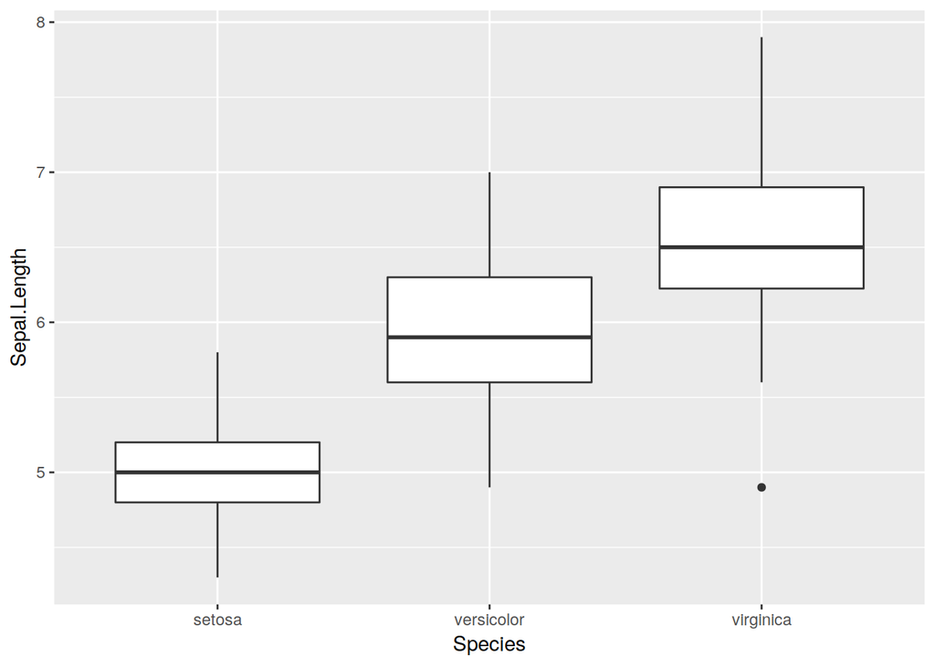

```r
library(ggplot2)
ggplot(iris, aes(x=Species, y=Sepal.Length)) + geom_boxplot()
```

La sintaxis es la sigueinte. Primero se introduce el data.frame en el cual están los datos que queremos representar. Después, mediante la función aes, determinamos el papel de cada variable que queremos usar en el gráfico. En el ejemplo anterior le hemos dicho que queremos que la variable species esté en el eje x y la variable Sepal.Length esté en el eje y. Una vez especificado el papel de cada variable, decimos el tipo de gráfico que queremos, en este caso un diagrama de cajas.

Pero también podríamos haber dicho que nos representase los puntos de datos de forma individual

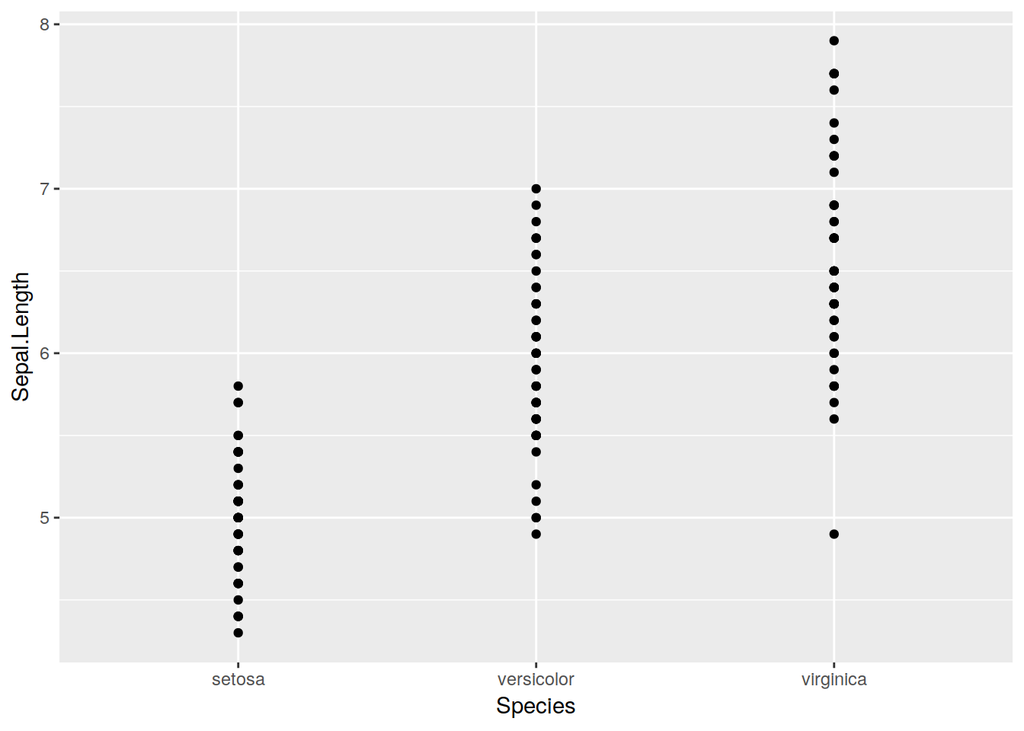

```r
ggplot(iris, aes(x=Species, y=Sepal.Length)) + geom_point()
```

Podemos asignar más de un papel a cada variable, por ejemplo, vamos a usar Species no solo para x, sino para determinar el color.

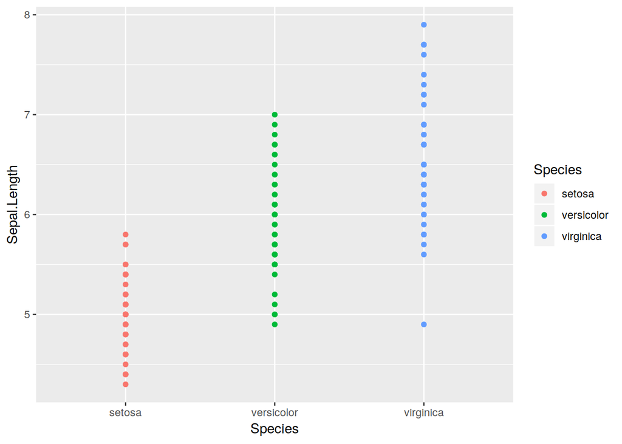

```r
ggplot(iris, aes(x=Species, y=Sepal.Length, color=Species)) + geom_point()
```

Tamibién podemos utilizar más de un tipo de representación. Por ejemplo, combinar el diagrama de cajas con los puntos

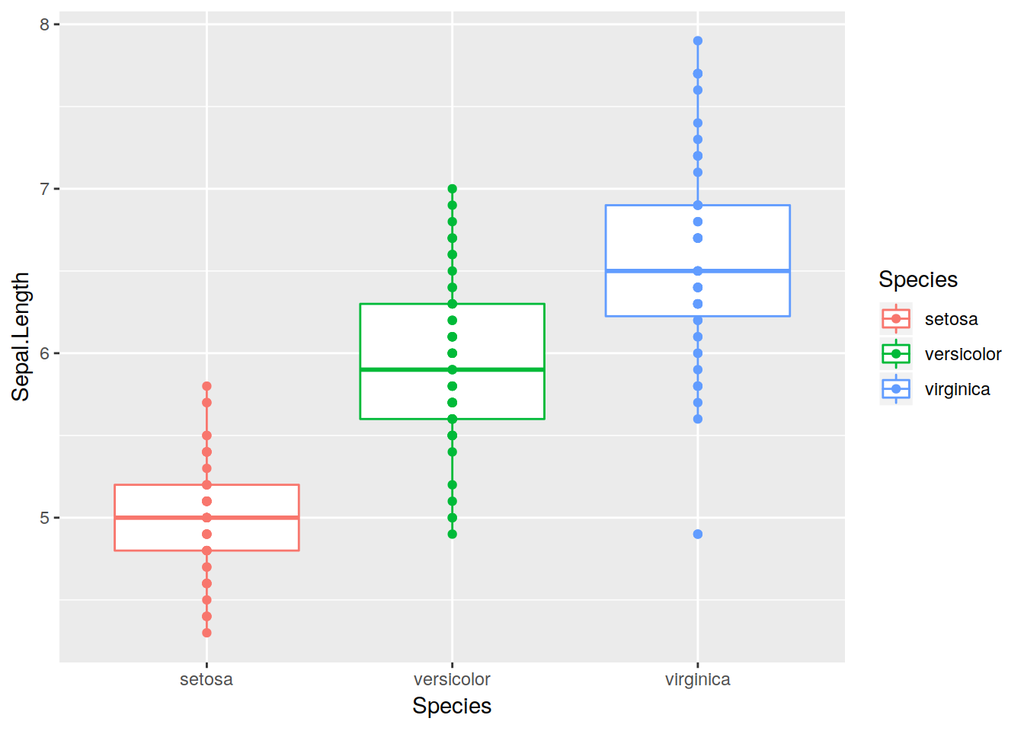

```r
ggplot(iris, aes(x=Species, y=Sepal.Length, color=Species)) + geom_boxplot() + geom_point()
```

Cuando elegimos el tipo de representación, hay que tener en cuanta dónde han sido asignadas las variables, ya que habrá representaciones que no se puedan hacer:

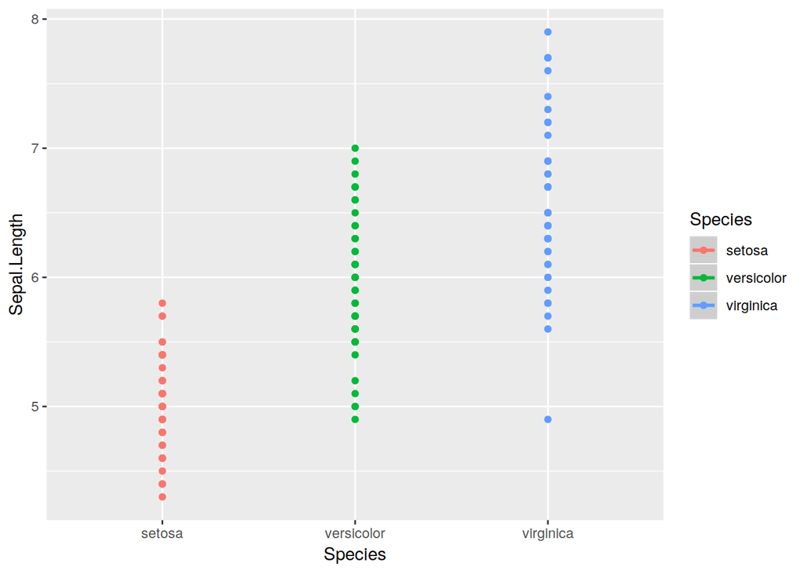

```r
ggplot(iris, aes(x=Species, y=Sepal.Length, color=Species)) + geom_smooth() + geom_point()
```

geom_smooth requiere que las dos variables x e y sean continuas

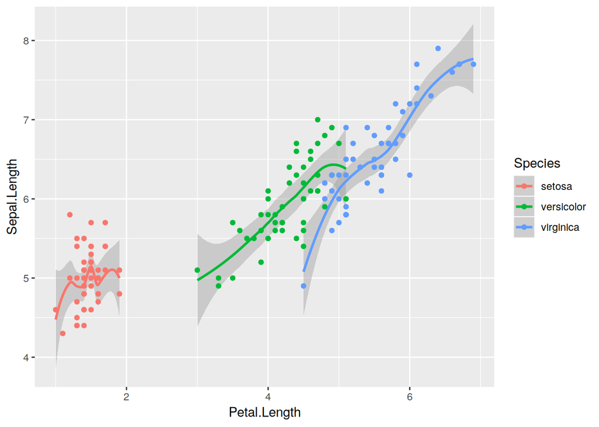

```r
ggplot(iris, aes(x=Petal.Length, y=Sepal.Length, color=Species)) + geom_smooth() + geom_point()
```